# Prak1_Pemulusan

Hanifa Rahmacindia Nasution

2023-09-01

# Akses Library

```r
library(forecast)
```

```r
library(graphics)
library(TTR)
library(TSA)
```

# Import Data

```r
library(rio)
gas <- import("https://raw.githubusercontent.com/HanifaNasution/Praktikum-MPDW/main/Data/Data%20Natural%20Gas%20Imputasi.csv")
View(gas)
str(gas)
```

```
## 'data.frame':    366 obs. of  8 variables:
##  $ Period  : int  1 2 3 4 5 6 7 8 9 10 ...
##  $ Date    : chr  "9/1/2021" "9/2/2021" "9/3/2021" "9/4/2021" ...
##  $ Open    : num  4.4 4.64 4.63 NA 4.73 ...
##  $ High    : num  4.71 4.73 4.72 NA 4.74 ...
##  $ Low     : num  4.38 4.58 4.59 NA 4.71 ...
##  $ Close   : num  4.62 4.64 4.71 NA 4.72 ...
##  $ Volume  : int  241159 176845 110953 NA NA NA 163663 244742 234848 151036 ...
##  $ Currency: chr  "USD" "USD" "USD" "USD" ...
```

```r
dim(gas)
```

```
## [1] 366   8
```

Ubah data tanggal ke mode “date”

```r
library(dplyr)
library(lubridate)
library(stringr)
gas_clean <- gas %>%
  mutate(Date = mdy(Date))
str(gas_clean)
```

```
## 'data.frame':    366 obs. of  8 variables:
##  $ Period  : int  1 2 3 4 5 6 7 8 9 10 ...
##  $ Date    : Date, format: "2021-09-01" "2021-09-02" ...
##  $ Open    : num  4.4 4.64 4.63 NA 4.73 ...
##  $ High    : num  4.71 4.73 4.72 NA 4.74 ...
##  $ Low     : num  4.38 4.58 4.59 NA 4.71 ...
##  $ Close   : num  4.62 4.64 4.71 NA 4.72 ...
##  $ Volume  : int  241159 176845 110953 NA NA NA 163663 244742 234848 151036 ...
##  $ Currency: chr  "USD" "USD" "USD" "USD" ...
```

Tampak bahwa kolom tanggal telah menggunakan mode “Date” bukan “chr” lagi

# Eksplorasi Data

Ringkasan data

```r
summary(gas_clean)
```

```
##      Period            Date                 Open            High
##  Min.   :  1.00   Min.   :2021-09-01   Min.   :3.589   Min.   :3.794
##  1st Qu.: 92.25   1st Qu.:2021-12-01   1st Qu.:4.640   1st Qu.:4.794
##  Median :183.50   Median :2022-03-02   Median :5.464   Median :5.736
##  Mean   :183.50   Mean   :2022-03-02   Mean   :5.978   Mean   :6.204
##  3rd Qu.:274.75   3rd Qu.:2022-06-01   3rd Qu.:7.357   3rd Qu.:7.678
##  Max.   :366.00   Max.   :2022-09-01   Max.   :9.780   Max.   :9.987
##                                        NA's   :100     NA's   :100
##       Low            Close           Volume         Currency
##  Min.   :3.536   Min.   :3.561   Min.   :  1200   Length:366
##  1st Qu.:4.510   1st Qu.:4.645   1st Qu.: 80658   Class :character
##  Median :5.348   Median :5.509   Median :117845   Mode  :character
##  Mean   :5.781   Mean   :5.988   Mean   :122270
##  3rd Qu.:7.003   3rd Qu.:7.371   3rd Qu.:159443
##  Max.   :9.200   Max.   :9.647   Max.   :305898
##  NA's   :100     NA's   :100     NA's   :115
```

Mengubah data agar terbaca sebagai data deret waktu

```r
gasopen.ts <- ts(gas_clean$Open)
gashigh.ts <- ts(gas_clean$High)
gaslow.ts <- ts(gas_clean$Low)
gasclose.ts <- ts(gas_clean$Close)
gasvolume.ts <- ts(gas_clean$Volume)
```

Membuat plot data deret waktu awal

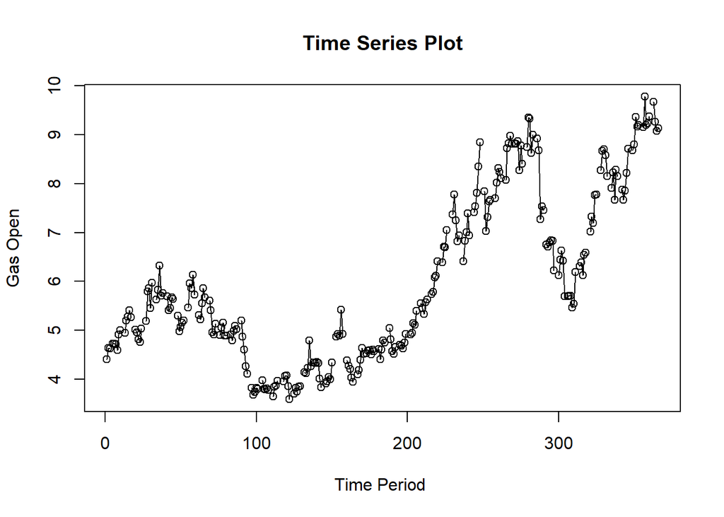

```r
ts.plot(gasopen.ts, xlab="Time Period ", ylab="Gas Open",
        main = "Time Series Plot")
points(gasopen.ts)
```

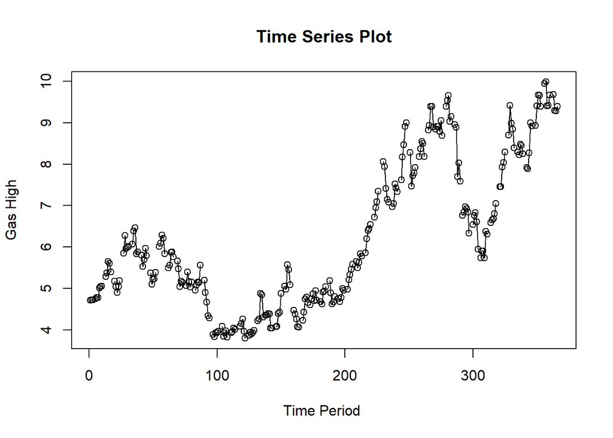

```r
ts.plot(gashigh.ts, xlab="Time Period ", ylab="Gas High",
        main = "Time Series Plot")
points(gashigh.ts)
```

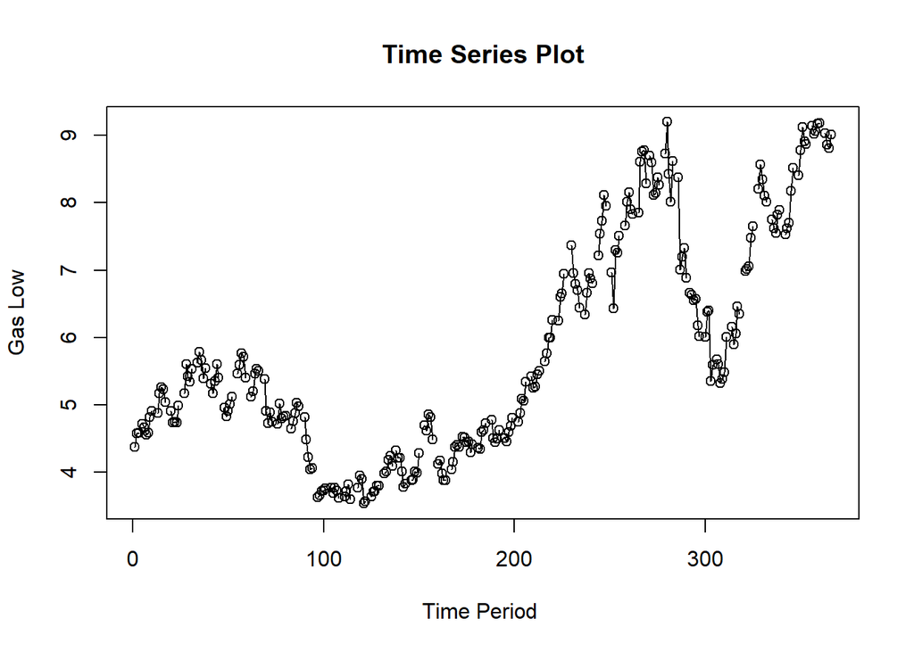

```r
ts.plot(gaslow.ts, xlab="Time Period ", ylab="Gas Low",
        main = "Time Series Plot")
points(gaslow.ts)
```

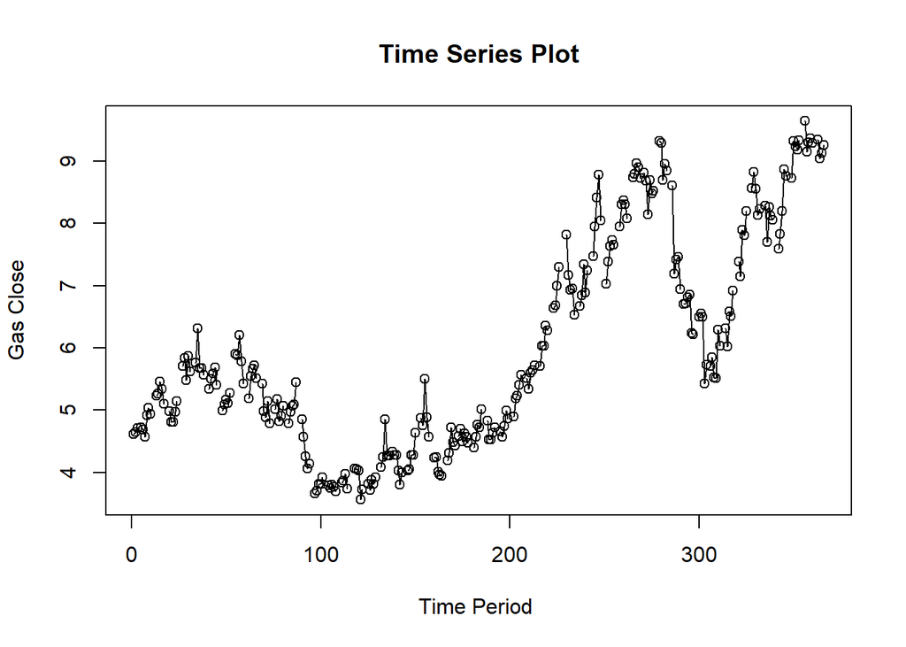

```r
ts.plot(gasclose.ts, xlab="Time Period ", ylab="Gas Close",
        main = "Time Series Plot")
points(gasclose.ts)
```

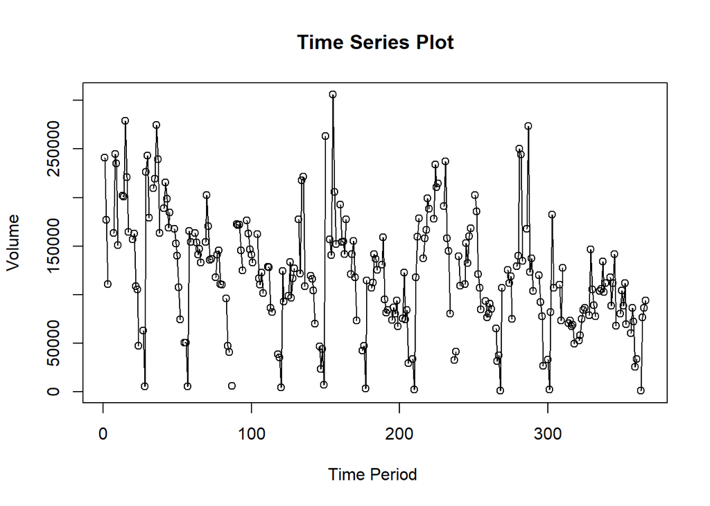

```r
ts.plot(gasvolume.ts, xlab="Time Period ", ylab="Volume",
        main = "Time Series Plot")
points(gasvolume.ts)
```

Berdasarkan plot data awal, tampak data memiliki pola trend sehingga akan lebih cocok jika menggunakan metode Double Moving Average atau Double Exponential Smoothing

# Imputasi Data Hilang

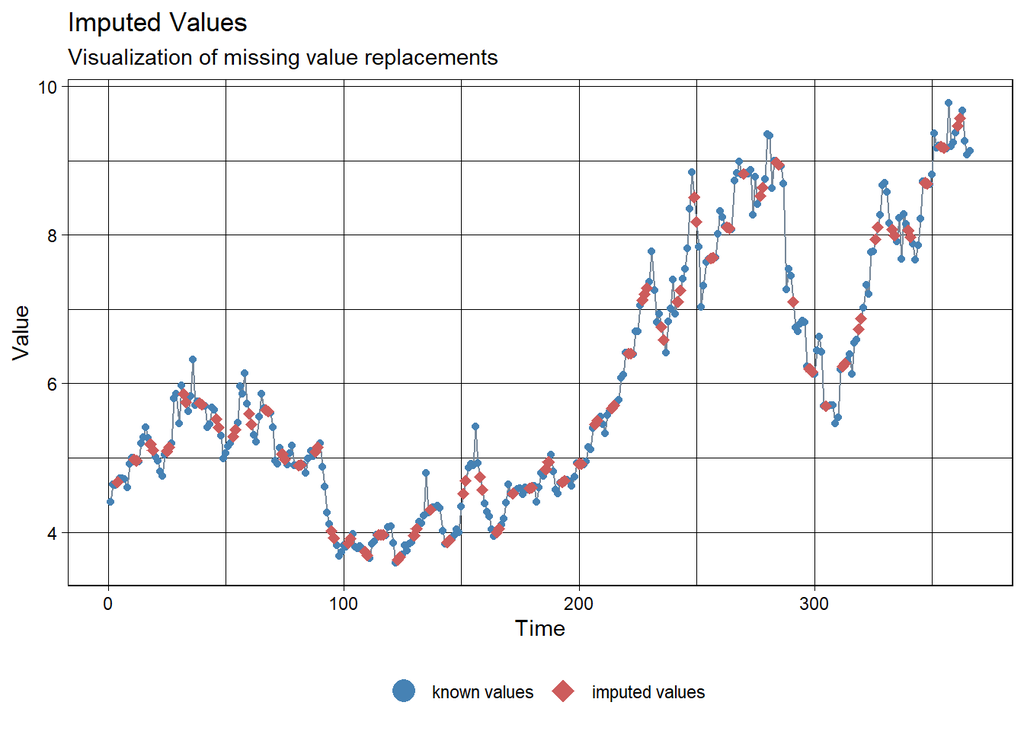

```r
#install.packages("imputeTS")
library(imputeTS)

gas.open<- na_interpolation(gas_clean$Open)
ggplot_na_imputations(gas_clean$Open,gas.open)
```

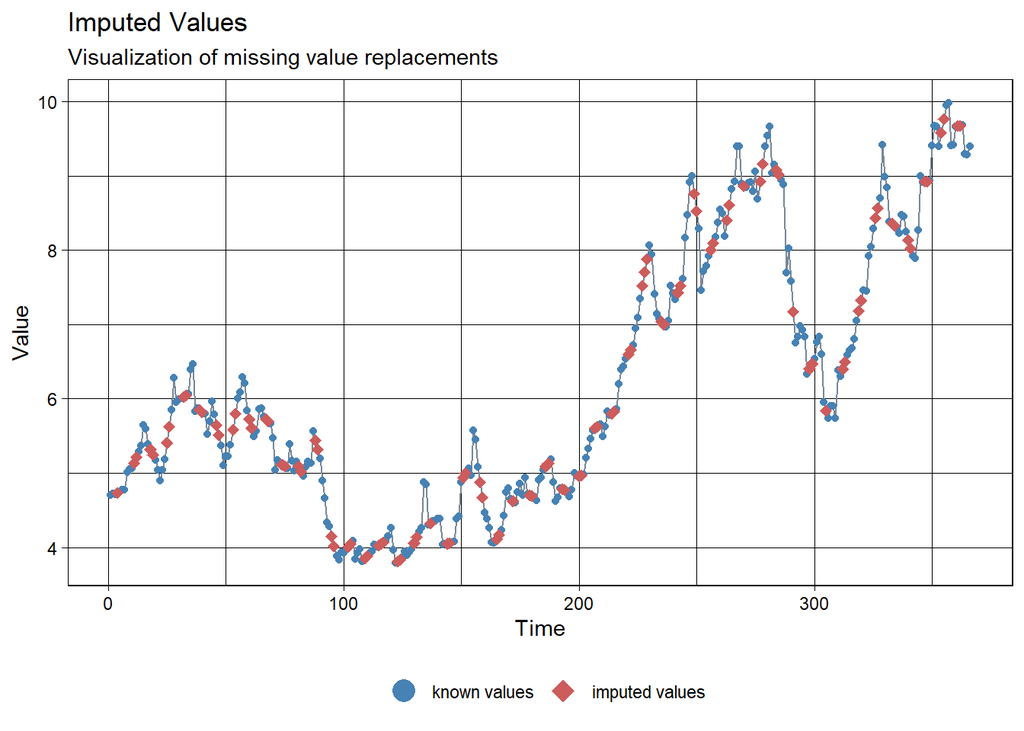

```r
gas.high<- na_interpolation(gas_clean$High)
ggplot_na_imputations(gas_clean$High,gas.high)
```

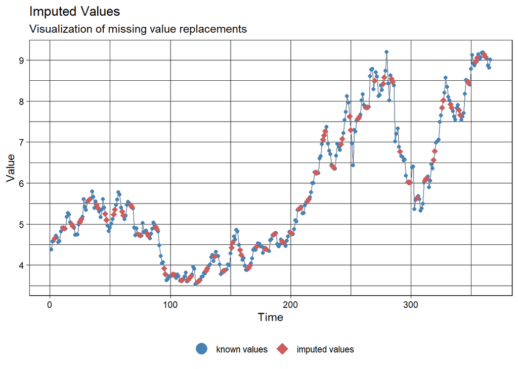

```r
gas.low<- na_interpolation(gas_clean$Low)
ggplot_na_imputations(gas_clean$Low,gas.low)
```

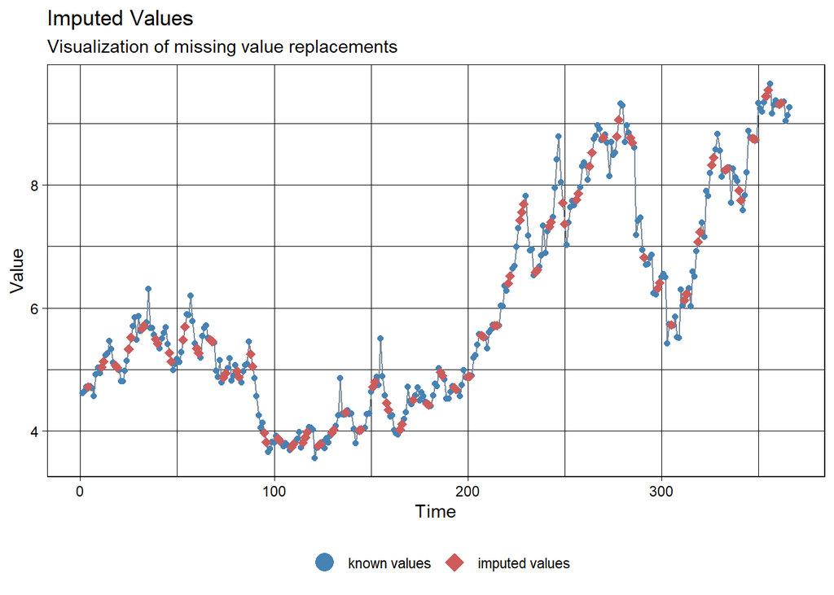

```r
gas.close <- na_interpolation(gas_clean$Close)
ggplot_na_imputations(gas_clean$Close,gas.close)
```

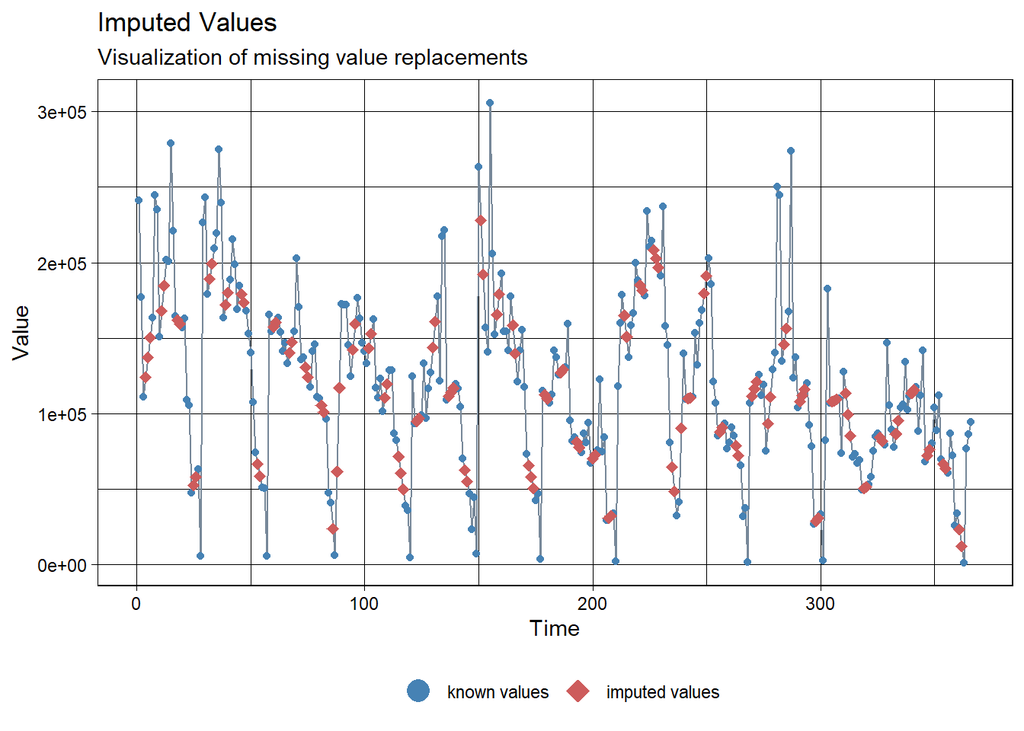

```r
gas.volume <- na_interpolation(gas_clean$Volume)
ggplot_na_imputations(gas_clean$Volume,gas.volume)
```

# Data Gas Baru Setelah Imputasi

```r
gas.imp <- data.frame(gas_clean$Period,gas_clean$Date,cbind(gas.open,gas.high,gas.low,gas.close,gas.volume),gas_clean$Currency)
View(gas.imp)
str(gas.imp)
```

```
## 'data.frame':    366 obs. of  8 variables:
##  $ gas_clean.Period  : int  1 2 3 4 5 6 7 8 9 10 ...
##  $ gas_clean.Date    : Date, format: "2021-09-01" "2021-09-02" ...
##  $ gas.open          : num  4.4 4.64 4.63 4.68 4.73 ...
##  $ gas.high          : num  4.71 4.73 4.72 4.73 4.74 ...
##  $ gas.low           : num  4.38 4.58 4.59 4.65 4.71 ...
##  $ gas.close         : num  4.62 4.64 4.71 4.72 4.72 ...
##  $ gas.volume        : num  241159 176845 110953 124131 137308 ...
##  $ gas_clean.Currency: chr  "USD" "USD" "USD" "USD" ...
```

```r
summary(gas.imp)
```

```
##  gas_clean.Period gas_clean.Date          gas.open        gas.high
##  Min.   :  1.00   Min.   :2021-09-01   Min.   :3.589   Min.   :3.794
##  1st Qu.: 92.25   1st Qu.:2021-12-01   1st Qu.:4.661   1st Qu.:4.794
##  Median :183.50   Median :2022-03-02   Median :5.484   Median :5.710
##  Mean   :183.50   Mean   :2022-03-02   Mean   :5.969   Mean   :6.193
##  3rd Qu.:274.75   3rd Qu.:2022-06-01   3rd Qu.:7.306   3rd Qu.:7.678
##  Max.   :366.00   Max.   :2022-09-01   Max.   :9.780   Max.   :9.987
##     gas.low        gas.close       gas.volume     gas_clean.Currency
##  Min.   :3.536   Min.   :3.561   Min.   :  1200   Length:366
##  1st Qu.:4.522   1st Qu.:4.684   1st Qu.: 78878   Class :character
##  Median :5.349   Median :5.503   Median :115310   Mode  :character
##  Mean   :5.776   Mean   :5.981   Mean   :119401
##  3rd Qu.:7.045   3rd Qu.:7.384   3rd Qu.:157808
##  Max.   :9.200   Max.   :9.647   Max.   :305898
```

```r
names(gas.imp)[1] <- "Period"
names(gas.imp)[2] <- "Date"
names(gas.imp)[3] <- "Open"
names(gas.imp)[4] <- "High"
names(gas.imp)[5] <- "Low"
names(gas.imp)[6] <- "Close"
names(gas.imp)[7] <- "Volume"
names(gas.imp)[8] <- "Currency"

View(gas.imp)

gasopen.ts <- ts(gas.imp$Open)
gashigh.ts <- ts(gas.imp$High)
gaslow.ts <- ts(gas.imp$Low)
gasclose.ts <- ts(gas.imp$Close)
gasvolume.ts <- ts(gas.imp$Volume)
```

# Pembagian Data Latih dan Data Uji

Data Latih 80% data awal Data Uji 20% data awal

```r
training_data <- gas.imp[1:293,]
testing_data <- gas.imp[293:366,]
```

# Memeriksa Apakah Ada Pola Musiman

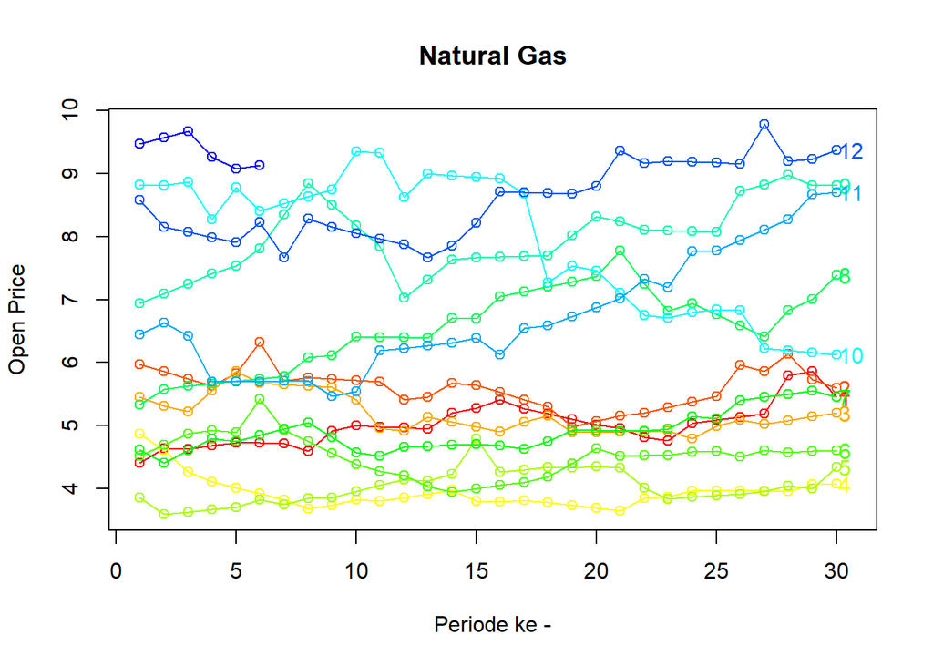

```r
gas.imp.open.ts <- ts(gas.imp$Open)
seasonplot(gas.imp.open.ts,30,
  main="Natural Gas",
  xlab = "Periode ke -",
  ylab = "Open Price",
  year.labels = TRUE, col=rainbow(18))
```

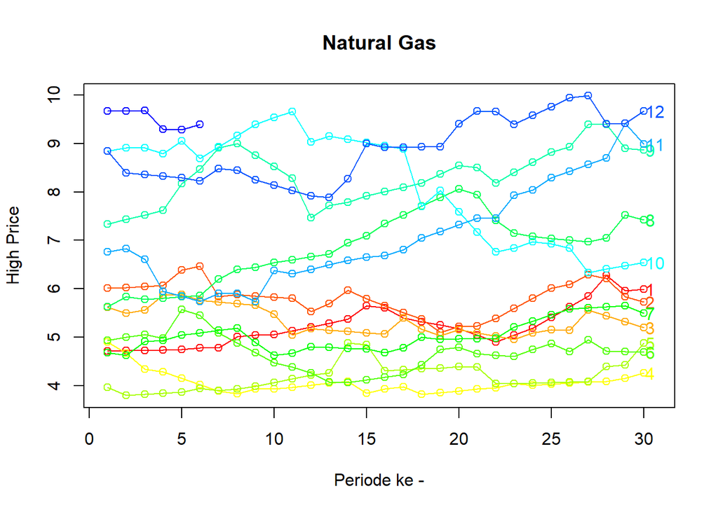

```r
gas.imp.high.ts <- ts(gas.imp$High)
seasonplot(gas.imp.high.ts,30,
  main="Natural Gas",
  xlab = "Periode ke -",
  ylab = "High Price",
  year.labels = TRUE, col=rainbow(18))
```

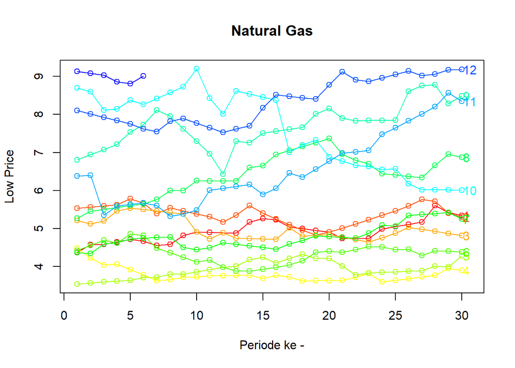

```r
gas.imp.low.ts <- ts(gas.imp$Low)
seasonplot(gas.imp.low.ts,30,
  main="Natural Gas",
  xlab = "Periode ke -",
  ylab = "Low Price",
  year.labels = TRUE, col=rainbow(18))
```

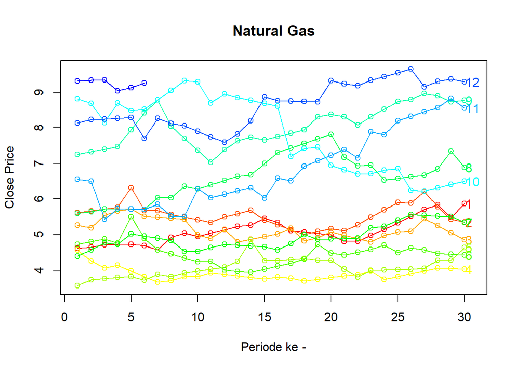

```r
gas.imp.close.ts <- ts(gas.imp$Close)
seasonplot(gas.imp.close.ts,30,
  main="Natural Gas",
  xlab = "Periode ke -",
  ylab = "Close Price",
  year.labels = TRUE, col=rainbow(18))
```

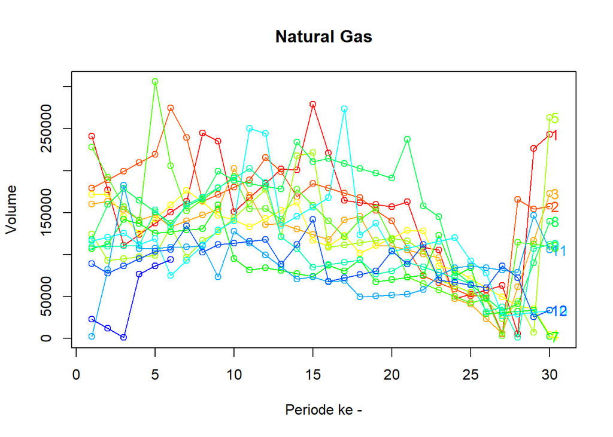

```r
gas.imp.volume.ts <- ts(gas.imp$Volume)
seasonplot(gas.imp.volume.ts,30,
  main="Natural Gas",
  xlab = "Periode ke -",
  ylab = "Volume",
  year.labels = TRUE, col=rainbow(18))
```

Berdasarkan grafik yang dihasilkan fungsi seasonplot tampak bahwa pada harga Open, High, Low, dan Close memiliki bentuk grafik yang mirip dan tidak ada pola musiman Sedangkan untuk data Volume perlu dikaji lebih lanjut (??)

# Pemulusan

Diduga dari plot awal data, data memiliki unsur trend sehingga akan cocok menggunakan pemulusan data trend namun untuk membuktikan apakah hal itu benar, akan dilakukan 2 metode pemulusan yaitu menggunakan Single Moving Average dan Double Moving Average

## Single Moving Average

### Pembagian Data

Data Latih 80% data awal Data Uji 20% data awal

```r
training_data <- gas.imp[1:293,]
testing_data <- gas.imp[294:366,]
train_ma.ts <- ts(training_data$High) #Menggunakan contoh High Price
test_ma.ts <- ts(testing_data$High)
```

### Eksplorasi Data

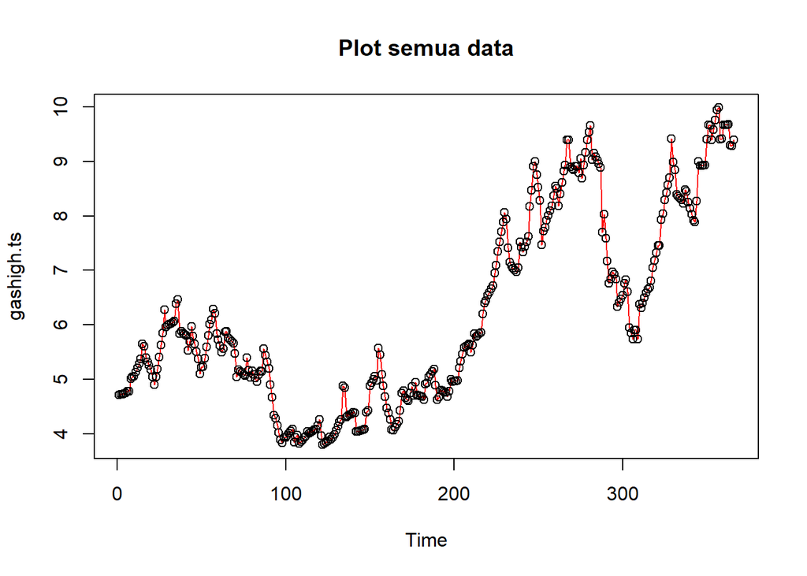

```r
#eksplorasi keseluruhan data
plot(gashigh.ts, col="red",main="Plot semua data")
points(gashigh.ts)
```

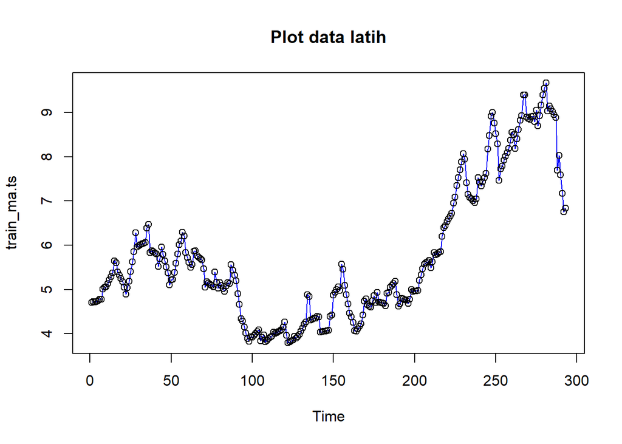

```r
#eksplorasi data latih
plot(train_ma.ts, col="blue",main="Plot data latih")
points(train_ma.ts)
```

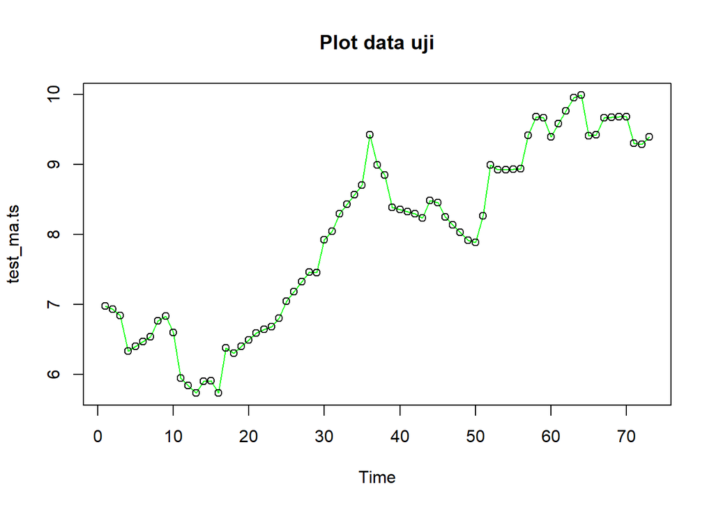

```r
#eksplorasi data uji
plot(test_ma.ts, col="green",main="Plot data uji")
points(test_ma.ts)
```

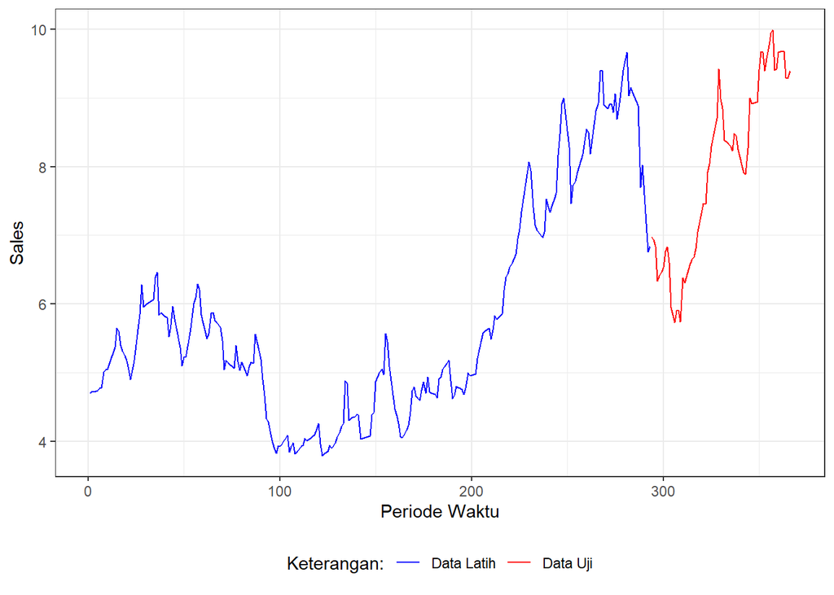

```r
#Eksplorasi dengan GGPLOT
library(ggplot2)
ggplot() +
  geom_line(data = training_data, aes(x = Period, y = training_data$High, col = "Data Latih")) +
  geom_line(data = testing_data, aes(x = Period, y = testing_data$High, col = "Data Uji")) +
  labs(x = "Periode Waktu", y = "Sales", color = "Legend") +
  scale_colour_manual(name="Keterangan:", breaks = c("Data Latih", "Data Uji"),
                      values = c("blue", "red")) +
  theme_bw() + theme(legend.position = "bottom",
                     plot.caption = element_text(hjust=0.5, size=12))
```

```r
data.sma<-SMA(train_ma.ts, n=6)
data.sma
```

```
## Time Series:
## Start = 1
## End = 293
## Frequency = 1
##   [1]       NA       NA       NA       NA       NA 4.732833 4.744167 4.791333
##   [9] 4.846167 4.900833 4.966333 5.039333 5.125167 5.185000 5.285500 5.375833
##  [17] 5.419000 5.437000 5.429833 5.397000 5.296333 5.179333 5.119833 5.097000
##  [25] 5.123611 5.199667 5.333833 5.564167 5.717167 5.852333 5.953056 6.019667
##  [33] 6.052167 6.016167 6.089000 6.167667 6.138500 6.113167 6.080556 6.040667
##  [41] 5.941833 5.784667 5.761000 5.775667 5.765444 5.736222 5.688000 5.662500
##  [49] 5.563667 5.439833 5.346167 5.301111 5.314278 5.385667 5.537000 5.682000
##  [57] 5.859333 5.997167 6.038556 6.026111 5.959833 5.860833 5.739833 5.683000
##  [65] 5.689500 5.695556 5.715111 5.748167 5.764500 5.698167 5.559833 5.462500
##  [73] 5.364722 5.268111 5.172667 5.105667 5.163667 5.161833 5.143667 5.150389
##  [81] 5.150278 5.143333 5.070500 5.056667 5.076333 5.073000 5.151722 5.221389
```

[output cut: 26 more lines]

```r
data.ramal<-c(NA,data.sma)
data.ramal #forecast 1 periode ke depan
```

```
##   [1]       NA       NA       NA       NA       NA       NA 4.732833 4.744167
##   [9] 4.791333 4.846167 4.900833 4.966333 5.039333 5.125167 5.185000 5.285500
##  [17] 5.375833 5.419000 5.437000 5.429833 5.397000 5.296333 5.179333 5.119833
##  [25] 5.097000 5.123611 5.199667 5.333833 5.564167 5.717167 5.852333 5.953056
##  [33] 6.019667 6.052167 6.016167 6.089000 6.167667 6.138500 6.113167 6.080556
##  [41] 6.040667 5.941833 5.784667 5.761000 5.775667 5.765444 5.736222 5.688000
##  [49] 5.662500 5.563667 5.439833 5.346167 5.301111 5.314278 5.385667 5.537000
##  [57] 5.682000 5.859333 5.997167 6.038556 6.026111 5.959833 5.860833 5.739833
##  [65] 5.683000 5.689500 5.695556 5.715111 5.748167 5.764500 5.698167 5.559833
##  [73] 5.462500 5.364722 5.268111 5.172667 5.105667 5.163667 5.161833 5.143667
##  [81] 5.150389 5.150278 5.143333 5.070500 5.056667 5.076333 5.073000 5.151722
##  [89] 5.221389 5.282000 5.301667 5.260000 5.181333 4.976833 4.784111 4.589333
##  [97] 4.392500 4.223500 4.084333 4.017000 3.956833 3.925667 3.923333 3.949833
## [105] 3.992500 3.977333 3.977667 3.979500 3.947667 3.915278 3.882333 3.896333
## [113] 3.899833 3.910667 3.942667 3.971931 3.998458 4.022250 4.045583 4.064417
```

[output cut: 22 more lines]

Selanjutnya akan dilakukan peramalan sejumlah data uji yaitu 73 periode. Pada metode SMA, hasil peramalan 73 periode ke depan akan bernilai sama dengan hasil peramalan 1 periode kedepan. Dalam hal ini akan dilakukan pengguabungan data aktual train, data hasil pemulusan dan data hasil ramalan 73 periode kedepan.

```r
data.gab<-cbind(aktual=c(train_ma.ts,rep(NA,73)),pemulusan=c(data.sma,rep(NA,73)),ramalan=c(data.ramal,rep(data.ramal[length(data.ramal)],73)))
data.gab #forecast 73 periode ke depan
```

```
##          aktual pemulusan  ramalan
##   [1,] 4.706000        NA       NA
##   [2,] 4.727000        NA       NA
##   [3,] 4.718000        NA       NA
##   [4,] 4.730000        NA       NA
##   [5,] 4.742000        NA       NA
##   [6,] 4.774000  4.732833       NA
##   [7,] 4.774000  4.744167 4.732833
##   [8,] 5.010000  4.791333 4.744167
##   [9,] 5.047000  4.846167 4.791333
##  [10,] 5.058000  4.900833 4.846167
##  [11,] 5.135000  4.966333 4.900833
##  [12,] 5.212000  5.039333 4.966333
##  [13,] 5.289000  5.125167 5.039333
##  [14,] 5.369000  5.185000 5.125167
```

[output cut: 353 more lines]

Adapun plot data deret waktu dari hasil peramalan yang dilakukan adalah sebagai berikut.

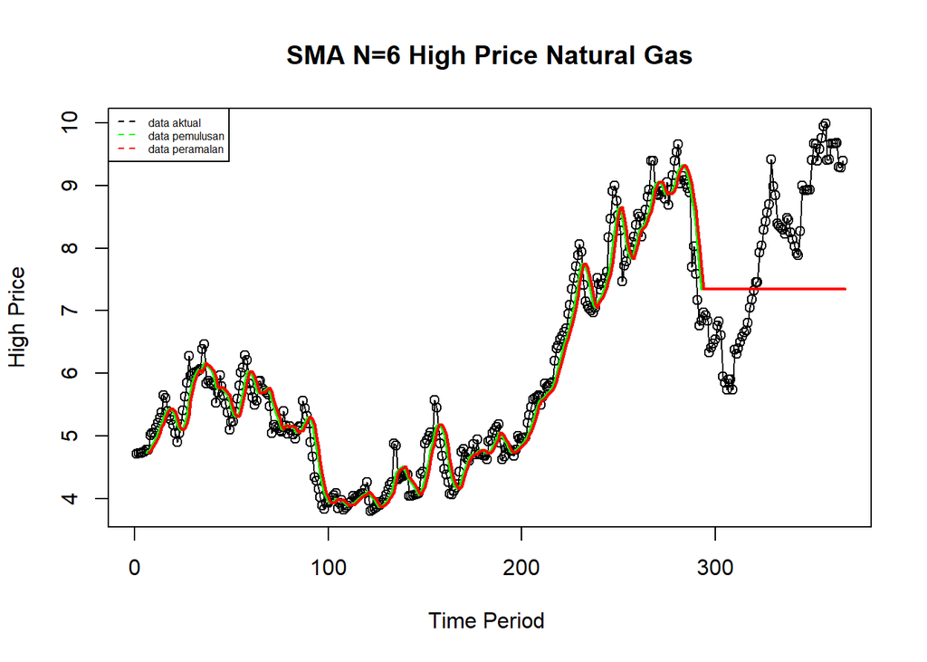

```r
ts.plot(gashigh.ts, xlab="Time Period ", ylab="High Price", main= "SMA N=6 High Price Natural Gas")
points(gashigh.ts)
lines(data.gab[,2],col="green",lwd=2)
lines(data.gab[,3],col="red",lwd=2)
legend("topleft",c("data aktual","data pemulusan","data peramalan"), lty=8, col=c("black","green","red"), cex=0.5)
```

### Perhitungan Akurasi

Selanjutnya perhitungan akurasi dilakukan dengan ukuran akurasi Sum Squares Error (SSE), Mean Square Error (MSE) dan Mean Absolute Percentage Error (MAPE). Perhitungan akurasi dilakukan baik pada data latih maupun pada data uji.

```r
#Menghitung nilai keakuratan data latih
error_train.sma = train_ma.ts-data.ramal[1:length(train_ma.ts)]
SSE_train.sma = sum(error_train.sma[5:length(train_ma.ts)]^2)
MSE_train.sma = mean(error_train.sma[5:length(train_ma.ts)]^2)
MAPE_train.sma = mean(abs((error_train.sma[5:length(train_ma.ts)]/train_ma.ts[5:length(train_ma.ts)])*100))

akurasi_train.sma <- matrix(c(SSE_train.sma, MSE_train.sma, MAPE_train.sma))
row.names(akurasi_train.sma)<- c("SSE", "MSE", "MAPE")
colnames(akurasi_train.sma) <- c("Akurasi m = 6")
akurasi_train.sma
```

```
##      Akurasi m = 6
## SSE             NA
## MSE             NA
## MAPE            NA
```

```r
#Menghitung nilai keakuratan data uji
error_test.sma = test_ma.ts-data.gab[294:366,3]
SSE_test.sma = sum(error_test.sma^2)
MSE_test.sma = mean(error_test.sma^2)
MAPE_test.sma = mean(abs((error_test.sma/test_ma.ts*100)))

akurasi_test.sma <- matrix(c(SSE_test.sma, MSE_test.sma, MAPE_test.sma))
row.names(akurasi_test.sma)<- c("SSE", "MSE", "MAPE")
colnames(akurasi_test.sma) <- c("Akurasi m = 6")
akurasi_test.sma
```

```
##      Akurasi m = 6
## SSE     148.753818
## MSE       2.037724
## MAPE     15.316164
```

Tampak bahwa menggunakan SMA kurang cocok untuk data tersebut

## Double Moving Average

### Pembagian Data

Data Latih 80% data awal Data Uji 20% data awal

```r
training_data <- gas.imp[1:293,]
testing_data <- gas.imp[294:366,]
train_ma.ts <- ts(training_data$High) #Menggunakan contoh High Price
test_ma.ts <- ts(testing_data$High)
```

### Eksplorasi Data

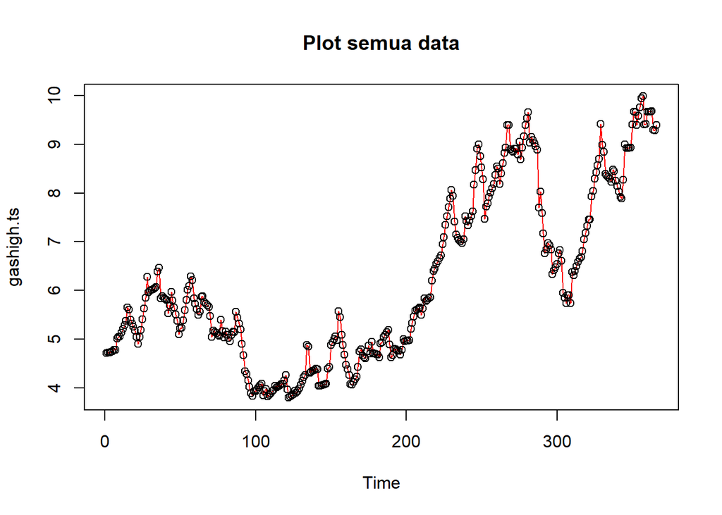

```r
#eksplorasi keseluruhan data
plot(gashigh.ts, col="red",main="Plot semua data")
points(gashigh.ts)
```

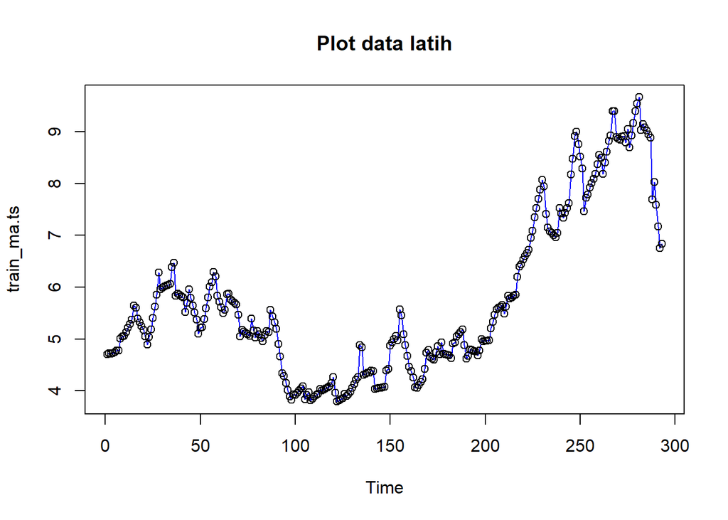

```r
#eksplorasi data latih
plot(train_ma.ts, col="blue",main="Plot data latih")
points(train_ma.ts)
```

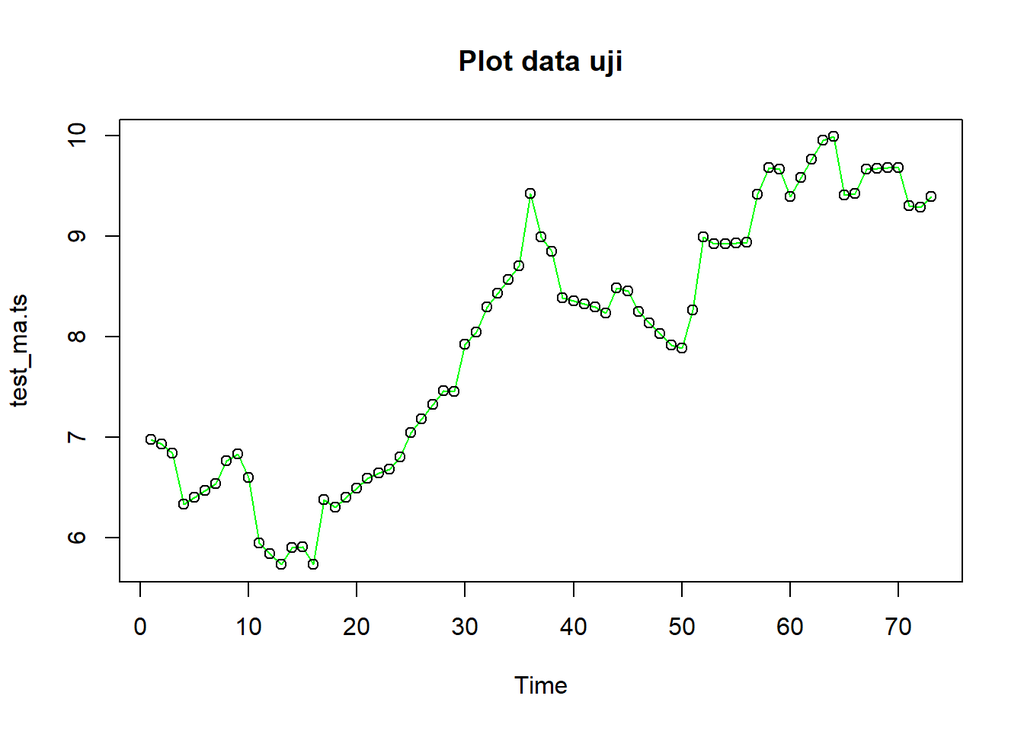

```r
#eksplorasi data uji
plot(test_ma.ts, col="green",main="Plot data uji")
points(test_ma.ts)
```

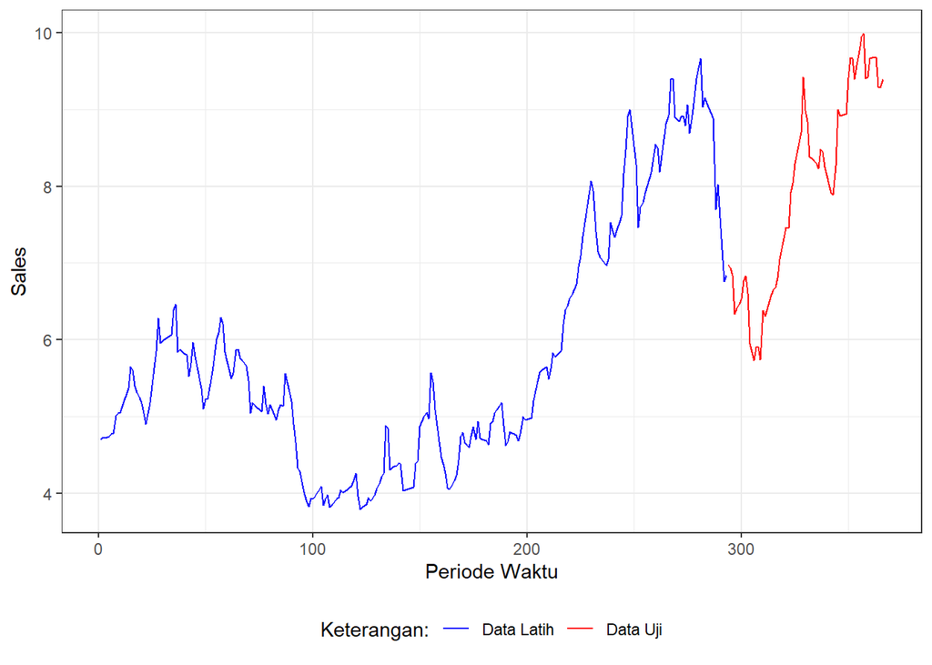

```r
#Eksplorasi dengan GGPLOT
library(ggplot2)
ggplot() +
  geom_line(data = training_data, aes(x = Period, y = training_data$High, col = "Data Latih")) +
  geom_line(data = testing_data, aes(x = Period, y = testing_data$High, col = "Data Uji")) +
  labs(x = "Periode Waktu", y = "Sales", color = "Legend") +
  scale_colour_manual(name="Keterangan:", breaks = c("Data Latih", "Data Uji"),
                      values = c("blue", "red")) +
  theme_bw() + theme(legend.position = "bottom",
                     plot.caption = element_text(hjust=0.5, size=12))
```

```r
dma <- SMA(data.sma, n = 6)
At <- 2*data.sma - dma
Bt <- 2/(4-1)*(data.sma - dma)
data.dma<- At+Bt
data.ramal2<- c(NA, data.dma)

t = 1:73
f = c()

for (i in t) {
  f[i] = At[length(At)] + Bt[length(Bt)]*(i)
}

data.gab2 <- cbind(aktual = c(train_ma.ts,rep(NA,73)), pemulusan1 = c(data.sma,rep(NA,73)),pemulusan2 = c(data.dma, rep(NA,73)),At = c(At, rep(NA,73)), Bt = c(Bt,rep(NA,73)),ramalan = c(data.ramal2, f[-1]))
data.gab2
```

```
##          aktual pemulusan1 pemulusan2       At            Bt     ramalan
##   [1,] 4.706000         NA         NA       NA            NA          NA
##   [2,] 4.727000         NA         NA       NA            NA          NA
##   [3,] 4.718000         NA         NA       NA            NA          NA
##   [4,] 4.730000         NA         NA       NA            NA          NA
##   [5,] 4.742000         NA         NA       NA            NA          NA
##   [6,] 4.774000   4.732833         NA       NA            NA          NA
##   [7,] 4.774000   4.744167         NA       NA            NA          NA
##   [8,] 5.010000   4.791333         NA       NA            NA          NA
##   [9,] 5.047000   4.846167         NA       NA            NA          NA
##  [10,] 5.058000   4.900833         NA       NA            NA          NA
##  [11,] 5.135000   4.966333   5.193093 5.102389  0.0907037037          NA
##  [12,] 5.212000   5.039333   5.302620 5.197306  0.1053148148   5.1930926
##  [13,] 5.289000   5.125167   5.425676 5.305472  0.1202037037   5.3026204
##  [14,] 5.369000   5.185000   5.475880 5.359528  0.1163518519   5.4256759
```

[output cut: 352 more lines]

Hasil pemulusan menggunakan metode DMA divisualisasikan sebagai berikut

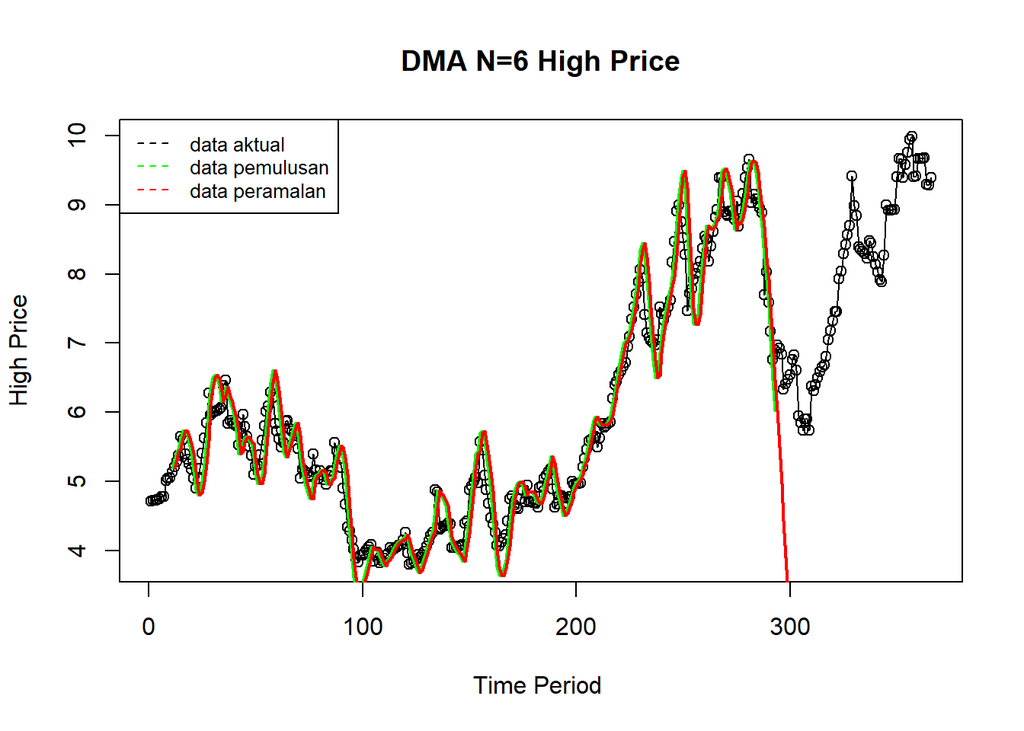

```r
ts.plot(gashigh.ts, xlab="Time Period ", ylab="High Price", main= "DMA N=6 High Price")
points(gashigh.ts)
lines(data.gab2[,3],col="green",lwd=2)
lines(data.gab2[,6],col="red",lwd=2)
legend("topleft",c("data aktual","data pemulusan","data peramalan"), lty=8, col=c("black","green","red"), cex=0.8)
```

Selanjutnya perhitungan akurasi dilakukan baik pada data latih maupun data uji. Perhitungan akurasi dilakukan dengan ukuran akurasi SSE, MSE dan MAPE.

```r
#Menghitung nilai keakuratan data latih
error_train.dma = train_ma.ts-data.ramal2[1:length(train_ma.ts)]
SSE_train.dma = sum(error_train.dma[8:length(train_ma.ts)]^2)
MSE_train.dma = mean(error_train.dma[8:length(train_ma.ts)]^2)
MAPE_train.dma = mean(abs((error_train.dma[8:length(train_ma.ts)]/train_ma.ts[8:length(train_ma.ts)])*100))

akurasi_train.dma <- matrix(c(SSE_train.dma, MSE_train.dma, MAPE_train.dma))
row.names(akurasi_train.dma)<- c("SSE", "MSE", "MAPE")
colnames(akurasi_train.dma) <- c("Akurasi m = 6")
akurasi_train.dma
```

```
##      Akurasi m = 6
## SSE             NA
## MSE             NA
## MAPE            NA
```

```r
#Menghitung nilai keakuratan data uji
error_test.dma = test_ma.ts-data.gab2[294:366,6]
SSE_test.dma = sum(error_test.dma^2)
MSE_test.dma = mean(error_test.dma^2)
MAPE_test.dma = mean(abs((error_test.dma/test_ma.ts*100)))

akurasi_test.dma <- matrix(c(SSE_test.dma, MSE_test.dma, MAPE_test.dma))
row.names(akurasi_test.dma)<- c("SSE", "MSE", "MAPE")
colnames(akurasi_test.dma) <- c("Akurasi m = 6")
akurasi_test.dma
```

```
##      Akurasi m = 6
## SSE     43528.5181
## MSE       596.2811
## MAPE      246.8460
```